# Culminating Activity

Calunod, Carumba, Gementiza, Mingo, Yu

2026-05-03

# Chapter 1

## Background of the Study

Artificial Intelligence has been growing substantially the past few years and it has been getting more capable for a lot of tasks in many professional areas. As organizations increasingly adopt AI-driven technologies, the concern about job displacement, automation risk, and shifting salary patterns have become central topics in both academic research and workforce planning.

The dataset captures these key variables across a projected time span of two decades. These datasets are made to reflect realistic relationships, for example, increasing AI adoption is often associated with higher productivity. The inclusion of future projections allows for predictive analysis, enabling researchers and students to explore possible scenarios in the evolving job market. This aligns with research efforts that aim to analyze how AI affects employment structures, wage distribution, and the demand for reskilling initiatives.

This study utilizes the AI Job Risk and Salary Dataset (2015-2035) to investigate the relationship between AI adoption, job risks levels, and salary trends. The findings of this study aim to contribute to a deeper understanding of workforce transformation and to provide data-driven insights that can guide career planning in an AI-driven world.

## Statement of the Problem

The rapid integration of AI into various industries has transformed job structures and skill requirements. While AI creates new opportunities, it introduces a pressing need to accurately identify which roles face the highest risk of automation based on underlying labor market metrics. Specifically, it seeks to answer the following questions:

1. What are the baseline characteristics of the dataset in terms of salary, skill demand scores, and job openings?
2. How are global occupations distributed across the High, Medium, and Low AI Risk categories?
3. How effectively can job roles be classified into distinct AI risk categories based on their numeric market factors?
4. What is the predictive accuracy of the kNN algorithm in determining the automation risk of a given occupation?

## Objectives of the Study

### General Objective

- To predict and classify the artificial intelligence automation risk of global job roles using machine learning techniques.

### Specific Objectives

- To describe the distribution of salaries, skill demand scores, and job openings across different global job roles.
- To evaluate the accuracy and predictive performance of the classification model.

## Significance of the Study

The following groups can benefit from the results of this research:

**Students and Job Seekers.** Individuals entering the workforce stand to benefit from a data-driven understanding of highly demanded, future-proof skills. The insights from this study can serve as a strategic guide, allowing them to make informed decisions regarding their educational pursuits, skill acquisition, and long-term career trajectories in an evolving labor market.

**Professionals and Employees.** Current members of the workforce can utilize the findings to accurately assess the automation risks associated with their specific roles. By understanding their job’s vulnerability to AI, professionals are empowered to proactively upskill or reskill, ensuring they remain relevant, adaptable, and competitive in a technology-driven work environment.

**Academic Institutions and Training Providers.** Educators, curriculum developers, and vocational trainers can utilize the findings to identify which technical skills are currently commanding high market demand and which roles are most susceptible to automation. This enables them to strategically adapt their curricula and advising programs, ensuring that learners are equipped with resilient competencies that align with actual industry needs.

**Employers and Human Resource Professionals.** Organizations and recruiters can leverage the study’s insights into skill demand and AI risk to forecast future workforce needs. This allows them to optimize talent acquisition strategies, design effective corporate training and reskilling programs, and better manage the organizational transition toward AI-integrated operations.

**Future Researchers.** This study contributes to the growing body of literature concerning the intersection of artificial intelligence, labor economics, and predictive career analytics. As such, it can serve as a foundational reference for future investigations involving broader global datasets, different economic sectors, or more advanced machine learning modeling techniques.

## Scope and Limitations

The study covers both historical and projected data from 2015 to 2035, aiming to identify patterns in how AI adoption influences employment opportunities, required skills, and compensation levels. The study primarily relies on quantitative data to generate insights, including relationships between job roles, emerging skills, and salary growth, as well as the potential risks of automation in different sectors.

However, the study is subject to several limitations. It depends solely on the variables available in the dataset, which may not fully capture all real-world factors affecting employment, such as economic fluctuations, government policies, or cultural influences. The projected data extending to 2035 is based on predictive models and assumptions, meaning actual future outcomes may differ. The study, additionally, does not incorporate qualitative perspectives, such as individual experiences or company-specific strategies, which could not provide deeper context.

# Chapter 2

## Related Studies

The dataset that the researchers chose explores the most relevant question that concerns the tech industry in today’s age: Will AI replace tech jobs in the near future? Hananto et al. (2025), in their systematic literature review of 18 peer-reviewed articles, investigated the dual impact of generative AI tools — particularly ChatGPT and GitHub Copilot — on programming careers. Their findings confirm that while AI automates routine tasks such as code generation, debugging, and unit testing (threatening entry-level roles), it simultaneously creates demand for higher-order competencies in AI integration, system design, and ethical governance. Notably, they cite evidence that AI pair-programming reduces task-completion time by over 55%, and that tools like GitHub Copilot solve roughly half of programming problems on the first attempt. The study concludes that generative AI should be viewed as a catalyst that redefines — rather than replaces – the human developer’s role. In this sense, AI will definitely change the roles of tech jobs; this does not mean that it will take over those jobs. It only means that with the tools at hand, requirements get more complicated; therefore, the expectation for these jobs becomes higher.

Complementing this qualitative evidence, the Future of Jobs AI Dataset (spanning 12,343 records across 10 job titles, 6 countries, and the period 2015–2035) – which, as aforementioned, was chosen by the researchers provides quantitative insight into how AI risk is distributed across the tech labor market. The dataset tracks variables including AI risk scores, skill demand scores, job survival classifications, and job openings. Analysis of this dataset reveals that Business Analysts carry the highest average AI risk score (0.75), followed by Data Analysts (0.65), while AI Researchers (0.15) and Cybersecurity Analysts (0.25) face the lowest risk. Interestingly, skill demand scores remain relatively stable across all roles (ranging from approximately 78.9 to 79.9 out of 100), suggesting that while AI displaces certain functions, it does not eliminate the overall demand for skilled human workers. Furthermore, the survival class distribution shows that roles like AI Researcher and ML Engineer are overwhelmingly classified as high-survival, while Business Analyst and Data Analyst skew toward lower survival — patterns that closely align with the risk scores reported in the qualitative literature.

## Related Literature

The tech economy can be regarded as a knowledge-based economy where human resources are valued as assets in both creative and technological domains. Thus, human resources are deemed as invaluable asset capital. According to Wuttahapan (2017), Human Capital Theory explains this phenomenon through an economic lens, asserting that investments in human capital–such as education, training, and accumulated experience–yield competitive advantage and sustainability for both individuals and organizations in a complex business world. As of now, human capital still remains the primary driver of organizational success, but the advancement of Artificial Intelligence introduces a new dynamic: the risk of technological automation or displacement. The valuation of human capital is no longer static; it is highly susceptible to technological disruption. As AI models become increasingly proficient in human tasks that require cognitive skills (such as basic programming, data analysis, or technical writing), the “AI Risk” associated with specific tech roles fluctuates. One’s vulnerability to AI displacement is intrinsically tied to one’s specific human capital profile. For example, jobs that are heavily reliant on routine coding tasks may exhibit higher AI risk compared to jobs requiring complex, strategic decision-making.

# Chapter 3

## Data Collection

This research utilizes secondary data sourced from Kaggle, a public repository for data science assets. The analysis is based exclusively on the “Future of Jobs AI Dataset”, which compiles comprehensive global employment metrics. In total, the dataset consists of 12,343 individual job entries characterized by 13 distinct variables related to career attributes, financial compensation, and automation vulnerability.

Usage of publicly available datasets is a standard methodological approach in predictive analytics. By utilizing open-source data, this study maintains a high degree of transparency, allowing future researchers to easily access the same files to replicate or verify the resulting models. Finally, ethical and privacy concerns are inherently minimized; the dataset provides generalized, macroeconomic market trends rather than sensitive, personally identifiable human information.

```r
data <- read.csv("dataset.csv")
head(data)
```

|  | job_title | country | experience_level | education_level | year | salary | ai_risk_score | primary_skill | skill_demand_score | job_openings | job_survival_class | salary_bucket | ai_risk_category |
| --- | --- | --- | --- | --- | --- | --- | --- | --- | --- | --- | --- | --- | --- |
| 1 | Data Scientist | USA | Senior | Master | 2022 | 61931.03 | 0.32 | Python | 88 | 39158 | 2 | High | Medium Risk |
| 2 | Software Engineer | India | Senior | Bachelor | 2032 | 21330.84 | 0.52 | Java | 80 | 7265 | 1 | High | Medium Risk |
| 3 | Data Scientist | Canada | Mid | Bachelor | 2015 | 24211.17 | 0.25 | Python | 70 | 22962 | 1 | High | Low Risk |
| 4 | Data Scientist | India | Entry | PhD | 2034 | 11794.86 | 0.44 | Python | 95 | 17023 | 1 | Medium | Medium Risk |
| 5 | Data Analyst | Canada | Entry | PhD | 2035 | 17999.26 | 0.75 | SQL | 61 | 3433 | 0 | Medium | High Risk |
| 6 | DevOps Engineer | UK | Entry | Master | 2033 | 29676.40 | 0.38 | Docker | 80 | 18568 | 1 | High | Medium Risk |

## Variables Description

### Dependent Variable

**AI Risk Category:** This is the main outcome we are trying to predict. Every job in the given dataset is grouped into one of three levels: Low Risk, Medium Risk, or High Risk. The goal of our computer model is to correctly guess which category a job belongs to based on its market factors.

## Data Analysis Techniques

### Descriptive Statistics

Descriptive statistics will be utilized to summarize the baseline characteristics of the scaled dataset prior to modeling. For the continuous predictor variables, measures of central tendency (mean and median) and dispersion (standard deviation and range) will be calculated to understand the data’s underlying distribution.

### Machine Learning (K-Nearest Neighbors Classification)

To predict an occupation’s vulnerability to automation, a supervised K-Nearest Neighbors (KNN) classification model will be deployed, designating `ai_risk_category` as the target dependent variable. The scaled dataset will be partitioned into two subsets: an 80% training set used to formulate the model’s pattern recognition, and a 20% testing set reserved strictly for out-of-sample validation.

The algorithmic hyperparameter for the optimal number of k-neighbors will be dynamically assigned based on the square root of the training dataset’s size. Finally, the model’s predictive performance and validity will be evaluated by constructing a confusion matrix to analyze class-specific predictive distributions, alongside the computation of the overall classification accuracy percentage.

# Chapter 4

## Results and Discussion

```r
# Libraries
library(class)
library(dplyr)
```

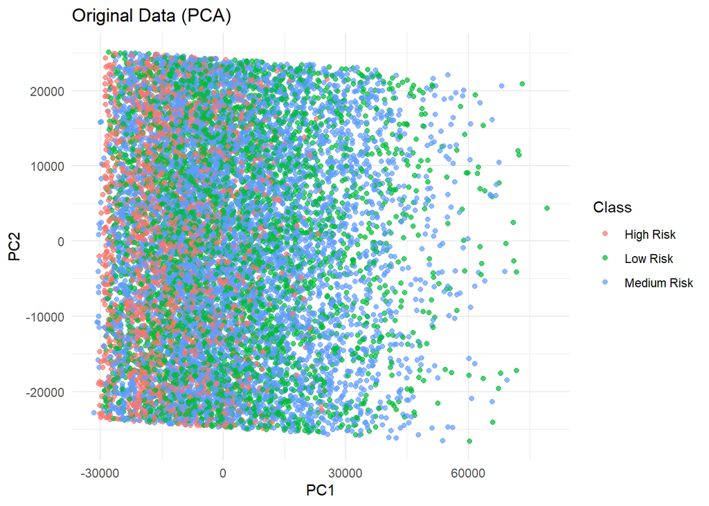

```r
library(ggplot2)

# Load data
data <- read.csv("dataset.csv")

# Clean data
data_clean <- data %>%
  select(-salary_bucket, -ai_risk_score, -primary_skill) %>%
  na.omit()

data_clean$ai_risk_category <- as.factor(data_clean$ai_risk_category)

# One-hot encoding
predictors <- model.matrix(~ . - ai_risk_category - 1, data = data_clean)
target <- data_clean$ai_risk_category

# Scaling
predictors_scaled <- scale(predictors)

# PCA (original)
pca_orig <- prcomp(predictors, center = TRUE, scale. = FALSE)

orig_df <- data.frame(
  PC1 = pca_orig$x[,1],
  PC2 = pca_orig$x[,2],
  Class = target
)

ggplot(orig_df, aes(PC1, PC2, color = Class)) +
  geom_point(alpha = 0.7) +
  ggtitle("Original Data (PCA)") +
  theme_minimal()
```

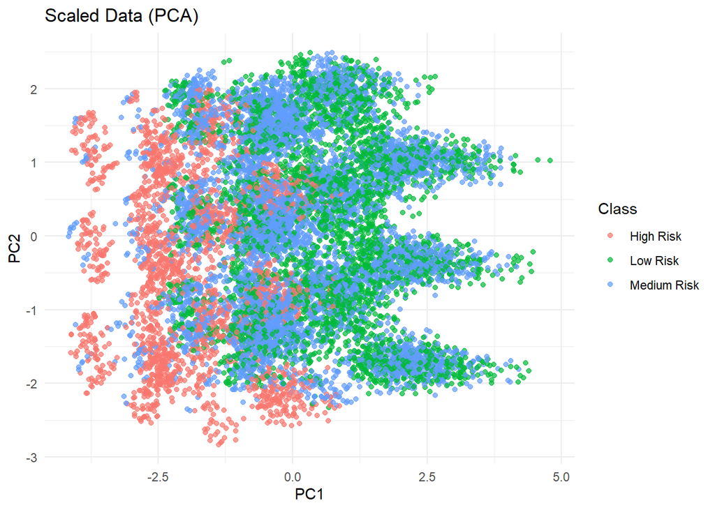

```r
# PCA (scaled)
pca_scaled <- prcomp(predictors_scaled)

scaled_df <- data.frame(
  PC1 = pca_scaled$x[,1],
  PC2 = pca_scaled$x[,2],
  Class = target
)

ggplot(scaled_df, aes(PC1, PC2, color = Class)) +
  geom_point(alpha = 0.7) +
  ggtitle("Scaled Data (PCA)") +
  theme_minimal()
```

```r
# Train-test split
set.seed(15)

train_index <- sample(1:nrow(predictors_scaled), 0.8 * nrow(predictors_scaled))

train_x <- predictors_scaled[train_index, ]
test_x  <- predictors_scaled[-train_index, ]

train_y <- target[train_index]
test_y  <- target[-train_index]

# k selection (sqrt rule, odd)
k_value <- round(sqrt(nrow(train_x)))
if (k_value %% 2 == 0) {
  k_value <- k_value + 1
}
print(paste("Final k:", k_value))
```

```
## [1] "Final k: 99"
```

```r
# kNN model
knn_predictions <- knn(train = train_x, test = test_x, cl = train_y, k = k_value)

# Evaluation
table(Predicted = knn_predictions, Actual = test_y)
```

```
##              Actual
## Predicted     High Risk Low Risk Medium Risk
##   High Risk         475        0          67
##   Low Risk            0      661         144
##   Medium Risk         0      114        1008
```

```r
accuracy <- mean(knn_predictions == test_y)
print(paste("Accuracy:", round(accuracy * 100, 2), "%"))
```

```
## [1] "Accuracy: 86.84 %"
```

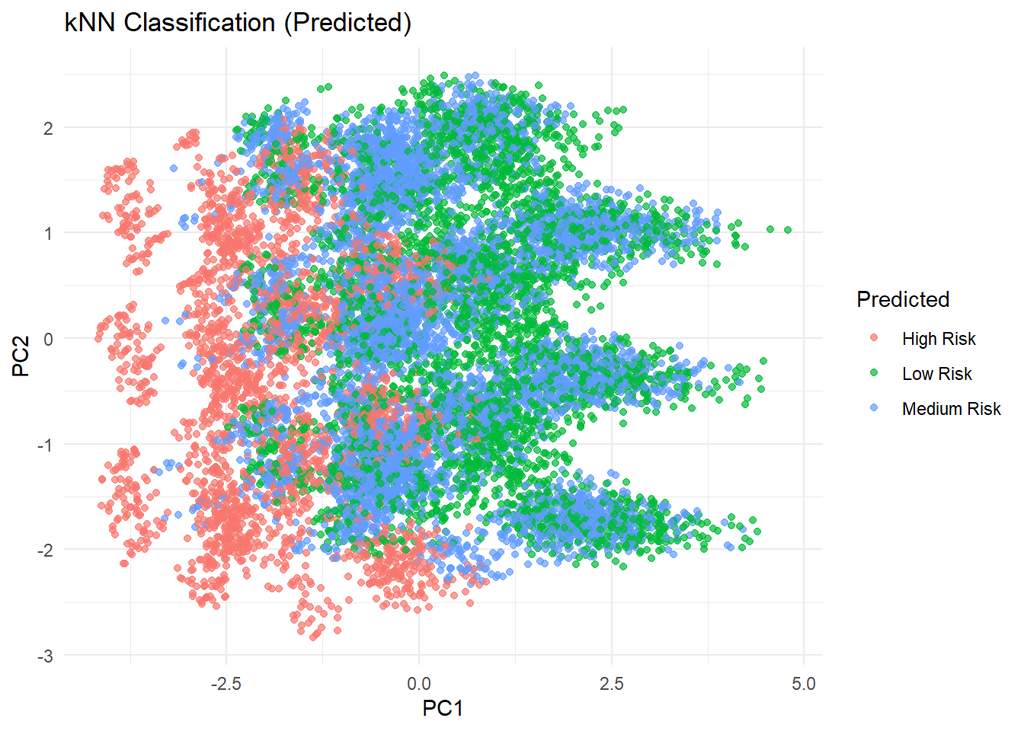

```r
# kNN visualization (PCA space)
full_knn <- knn(train = train_x, test = predictors_scaled, cl = train_y, k = k_value)

knn_df <- data.frame(
  PC1 = pca_scaled$x[,1],
  PC2 = pca_scaled$x[,2],
  Predicted = full_knn
)

ggplot(knn_df, aes(PC1, PC2, color = Predicted)) +
  geom_point(alpha = 0.7) +
  ggtitle("kNN Classification (Predicted)") +
  theme_minimal()
```

```r
# Ensure the caret library is loaded
if(!require(caret)) install.packages("caret")
library(caret)

# Generate the full confusion matrix and statistics
# We use 'mode = everything' to ensure F1 and other metrics are calculated
cM <- confusionMatrix(knn_predictions, test_y, mode = "everything")

# Display the overall accuracy and global statistics
print(cM$overall)
```

```
##       Accuracy          Kappa  AccuracyLower  AccuracyUpper   AccuracyNull
##      0.8683678      0.7914109      0.8543918      0.8814633      0.4937222
## AccuracyPValue  McnemarPValue
##      0.0000000            NaN
```

```r
# Display class-specific metrics (Sensitivity, Specificity, F1, etc.)
print(cM$byClass)
```

```
##                    Sensitivity Specificity Pos Pred Value Neg Pred Value
## Class: High Risk     1.0000000   0.9663992      0.8763838      1.0000000
## Class: Low Risk      0.8529032   0.9149941      0.8211180      0.9314904
## Class: Medium Risk   0.8269073   0.9088000      0.8983957      0.8433556
##                    Precision    Recall        F1 Prevalence Detection Rate
## Class: High Risk   0.8763838 1.0000000 0.9341200  0.1923856      0.1923856
## Class: Low Risk    0.8211180 0.8529032 0.8367089  0.3138923      0.2677197
## Class: Medium Risk 0.8983957 0.8269073 0.8611704  0.4937222      0.4082625
##                    Detection Prevalence Balanced Accuracy
## Class: High Risk              0.2195221         0.9831996
## Class: Low Risk               0.3260429         0.8839487
## Class: Medium Risk            0.4544350         0.8678537
```

```r
# 1. Libraries
library(class)
library(dplyr)
library(ggplot2)
library(caret)
library(reshape2) # For heatmap

# 2. Load and Initial Summary
data <- read.csv("dataset.csv")

# Descriptive Statistics: Numerical baseline
print("--- Baseline Numerical Characteristics ---")
```

```
## [1] "--- Baseline Numerical Characteristics ---"
```

```r
summary(data %>% select(where(is.numeric)))
```

```
##       year          salary       ai_risk_score   skill_demand_score
##  Min.   :2015   Min.   :  3875   Min.   :0.050   Min.   :60.00
##  1st Qu.:2020   1st Qu.: 21331   1st Qu.:0.260   1st Qu.:70.00
##  Median :2025   Median : 31573   Median :0.360   Median :79.00
##  Mean   :2025   Mean   : 34554   Mean   :0.396   Mean   :79.45
##  3rd Qu.:2030   3rd Qu.: 45308   3rd Qu.:0.490   3rd Qu.:89.00
##  Max.   :2035   Max.   :113589   Max.   :0.850   Max.   :99.00
##   job_openings   job_survival_class
##  Min.   : 1002   Min.   :0.00
##  1st Qu.:12993   1st Qu.:1.00
##  Median :24896   Median :1.00
##  Mean   :25224   Mean   :1.31
##  3rd Qu.:37441   3rd Qu.:2.00
##  Max.   :49998   Max.   :2.00
```

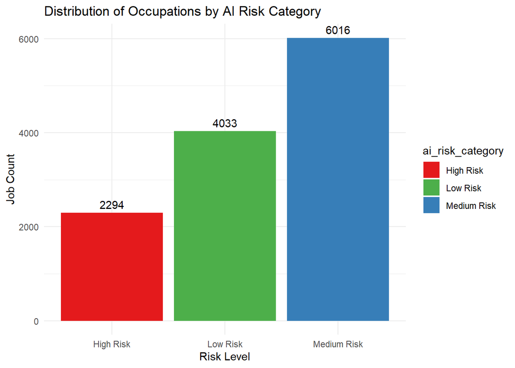

```r
# Descriptive Statistics: Distribution of Risk Categories
ggplot(data, aes(x = ai_risk_category, fill = ai_risk_category)) +
  geom_bar() +
  geom_text(stat='count', aes(label=..count..), vjust=-0.5) +
  scale_fill_manual(values = c("High Risk" = "#e41a1c", "Medium Risk" = "#377eb8", "Low Risk" = "#4daf4a")) +
  labs(title = "Distribution of Occupations by AI Risk Category", x = "Risk Level", y = "Job Count") +
  theme_minimal()
```

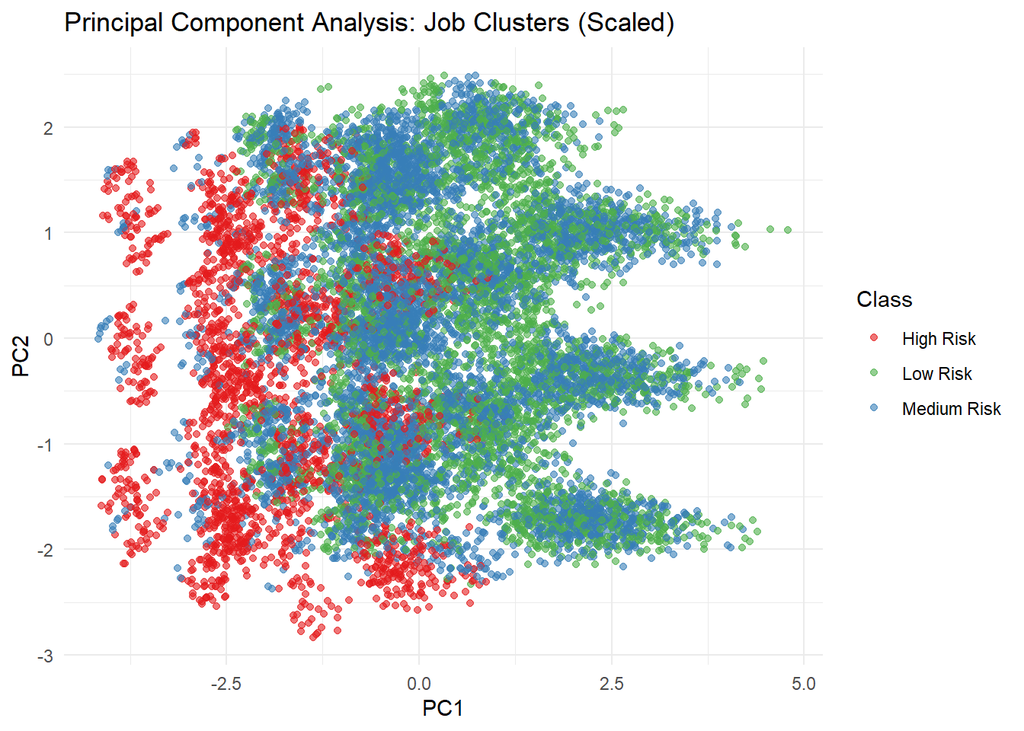

```r
# 3. Clean and Preprocess
data_clean <- data %>%
  select(-salary_bucket, -ai_risk_score, -primary_skill) %>%
  na.omit()

data_clean$ai_risk_category <- as.factor(data_clean$ai_risk_category)

# One-hot encoding & Scaling
predictors <- model.matrix(~ . - ai_risk_category - 1, data = data_clean)
target <- data_clean$ai_risk_category
predictors_scaled <- scale(predictors)

# 4. PCA Analysis (Dimensionality Reduction)
pca_scaled <- prcomp(predictors_scaled)
scaled_df <- data.frame(PC1 = pca_scaled$x[,1], PC2 = pca_scaled$x[,2], Class = target)

ggplot(scaled_df, aes(PC1, PC2, color = Class)) +
  geom_point(alpha = 0.6) +
  scale_color_manual(values = c("#e41a1c", "#4daf4a", "#377eb8")) +
  ggtitle("Principal Component Analysis: Job Clusters (Scaled)") +
  theme_minimal()
```

```r
# 5. Modeling (kNN)
set.seed(15)
train_index <- sample(1:nrow(predictors_scaled), 0.8 * nrow(predictors_scaled))
train_x <- predictors_scaled[train_index, ]
test_x  <- predictors_scaled[-train_index, ]
train_y <- target[train_index]
test_y  <- target[-train_index]

k_value <- round(sqrt(nrow(train_x)))
if (k_value %% 2 == 0) k_value <- k_value + 1

knn_predictions <- knn(train = train_x, test = test_x, cl = train_y, k = k_value)

# 6. Advanced Evaluation Metrics
cM <- confusionMatrix(knn_predictions, test_y, mode = "everything")
print(cM)
```

```
## Confusion Matrix and Statistics
##
##              Reference
## Prediction    High Risk Low Risk Medium Risk
##   High Risk         475        0          67
##   Low Risk            0      661         144
##   Medium Risk         0      114        1008
##
## Overall Statistics
##
##                Accuracy : 0.8684
##                  95% CI : (0.8544, 0.8815)
##     No Information Rate : 0.4937
##     P-Value [Acc > NIR] : < 2.2e-16
##
##                   Kappa : 0.7914
##
##  Mcnemar's Test P-Value : NA
##
## Statistics by Class:
##
##                      Class: High Risk Class: Low Risk Class: Medium Risk
## Sensitivity                    1.0000          0.8529             0.8269
## Specificity                    0.9664          0.9150             0.9088
## Pos Pred Value                 0.8764          0.8211             0.8984
## Neg Pred Value                 1.0000          0.9315             0.8434
## Precision                      0.8764          0.8211             0.8984
## Recall                         1.0000          0.8529             0.8269
## F1                             0.9341          0.8367             0.8612
## Prevalence                     0.1924          0.3139             0.4937
## Detection Rate                 0.1924          0.2677             0.4083
## Detection Prevalence           0.2195          0.3260             0.4544
## Balanced Accuracy              0.9832          0.8839             0.8679
```

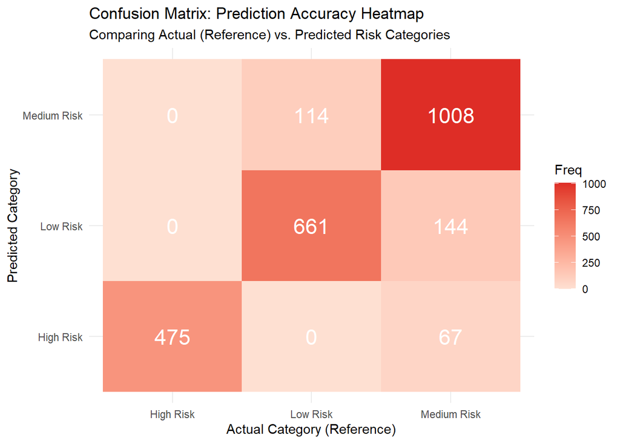

```r
# 7. Visualization: Confusion Matrix Heatmap
# Converting the table to a data frame
cm_df <- as.data.frame(cM$table)

# Check names just to be safe: they are usually 'Prediction', 'Reference', and 'Freq'
# We will use the exact names generated by as.data.frame(table)
ggplot(cm_df, aes(x = Reference, y = Prediction, fill = Freq)) +
  geom_tile() +
  geom_text(aes(label = Freq), color = "white", size = 6) +
  scale_fill_gradient(low = "#fee0d2", high = "#de2d26") +
  labs(title = "Confusion Matrix: Prediction Accuracy Heatmap",
       subtitle = "Comparing Actual (Reference) vs. Predicted Risk Categories",
       x = "Actual Category (Reference)",
       y = "Predicted Category") +
  theme_minimal()
```

```r
# 8. Identifying High-Risk Job Roles
# Append predictions back to the original data
data_final <- data
# Note: We run kNN on the full dataset to get predictions for all roles
full_predictions <- knn(train = train_x, test = predictors_scaled, cl = train_y, k = k_value)
data_final$model_prediction <- full_predictions

# Extracting a specific list of job roles classified as High Risk
high_risk_roles <- data_final %>%
  filter(model_prediction == "High Risk") %>%
  select(job_title, ai_risk_category, model_prediction) %>%
  distinct()

mid_risk_roles <- data_final %>%
  filter(model_prediction == "Medium Risk") %>%
  select(job_title, ai_risk_category, model_prediction) %>%
  distinct()

print("--- Sample of Job Roles Classified as High Risk ---")
```

```
## [1] "--- Sample of Job Roles Classified as High Risk ---"
```

```r
head(high_risk_roles, 20)
```

|  | job_title | ai_risk_category | model_prediction |
| --- | --- | --- | --- |
| 1 | Data Analyst | High Risk | High Risk |
| 2 | Business Analyst | High Risk | High Risk |
| 3 | Data Analyst | Medium Risk | High Risk |

```r
print("--- Sample of Job Roles Classified as Medium Risk ---")
```

```
## [1] "--- Sample of Job Roles Classified as Medium Risk ---"
```

```r
head(mid_risk_roles, 20)
```

|  | job_title | ai_risk_category | model_prediction |
| --- | --- | --- | --- |
| 1 | Data Scientist | Medium Risk | Medium Risk |
| 2 | Software Engineer | Medium Risk | Medium Risk |
| 3 | Data Scientist | Low Risk | Medium Risk |
| 4 | DevOps Engineer | Medium Risk | Medium Risk |
| 5 | Cloud Engineer | Medium Risk | Medium Risk |
| 6 | Product Manager | Medium Risk | Medium Risk |
| 7 | DevOps Engineer | Low Risk | Medium Risk |
| 8 | Cloud Engineer | Low Risk | Medium Risk |
| 9 | ML Engineer | Medium Risk | Medium Risk |
| 10 | Cybersecurity Analyst | Medium Risk | Medium Risk |

[output cut: 1 more lines]